# persamaan linear

### APA YANG DIMAKSUD PERSAMAAN LINEAR?

Secara matematis,persamaan linear adalah sebuah persamaan yang memiliki derajat (pangkat) tertinggi satu. Jika sebuah persamaan memiliki variabel x atau y, maka variabel tersebut tidak boleh memiliki pangkat selain satu (misal:x^2, X^3, dst tidak diperbolehkan).

Bentuk standar persamaan linear dengan n variabel adalah:

a_1 x_1 + a_2 x_2 + ... + a_n x_n = b\

Dimana:

- a_1, a_2, ... : adalah koefisien (angka pendamping variabel)
- x_1, x_2, ... : adalah variabel (nilai yang belum diketahui)
- b : adalah konstanta

Dalam ruang dua dimensi (2D) setiap pasangan nilai (x,y) yang memenuhi persamaan tersebut, jika dihubungkan akan membentuk garis lurus (line) yang tidak terputus dan tidak berbelok. Secara geometris, persamaan linear mempresentasikan perubahan yang konstan. Jika nilai x bertambah, maka nilai y akan bertambah (atau berkurang) dengan rasio yang tetap. Itulah yang disebut gradien atau kemiringan garis.

Persamaan linear memiliki sifat-sifat unik yang membedakannya dari persamaan non-linear (seperti kuadrat atau eksponensial):

1. Sifat penjumlahan: Kita bisa menambahkan atau mengurangi kedua ruas dengan angka yang sama tanpa mengubah nilai kebenaran persamaan.
2. Sifat perkalian :Kita bisa mengali atau membagi kedua ruas dengan angka yang sama (selama bukan nol).
3. Visualisasi: Didalam koordinat kartesius, ia tidak akan pernah memiliki titik puncak atau lembah (parabola), melainkan membentang lurus hingga tak terhingga.

Buat dua persamaan linear dengan dua variabel!

persamaan 1:  
f: 3x + 4y = 24  
g: 5X - 2y = 14

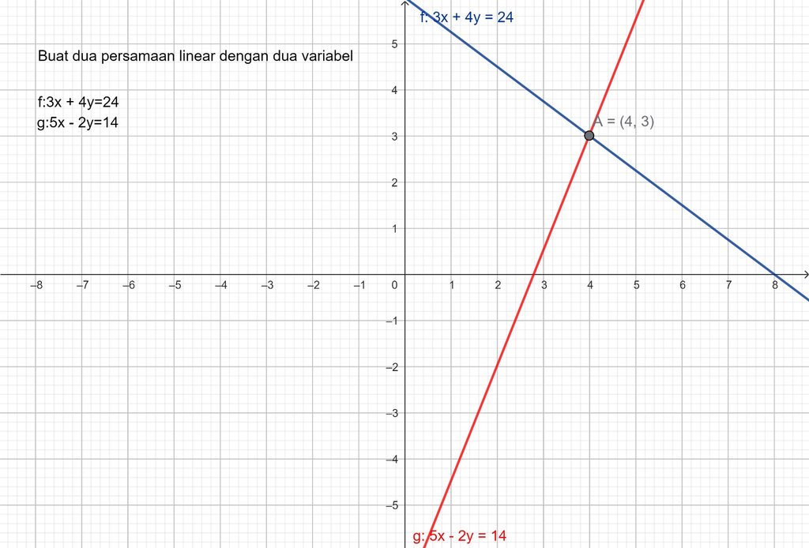

```python
from IPython.display import Image
Image(filename="persamaan 1.jpeg")
```

persamaan 2:  
f: 3x + 2y = 10  
g: 2x + 5y = 14

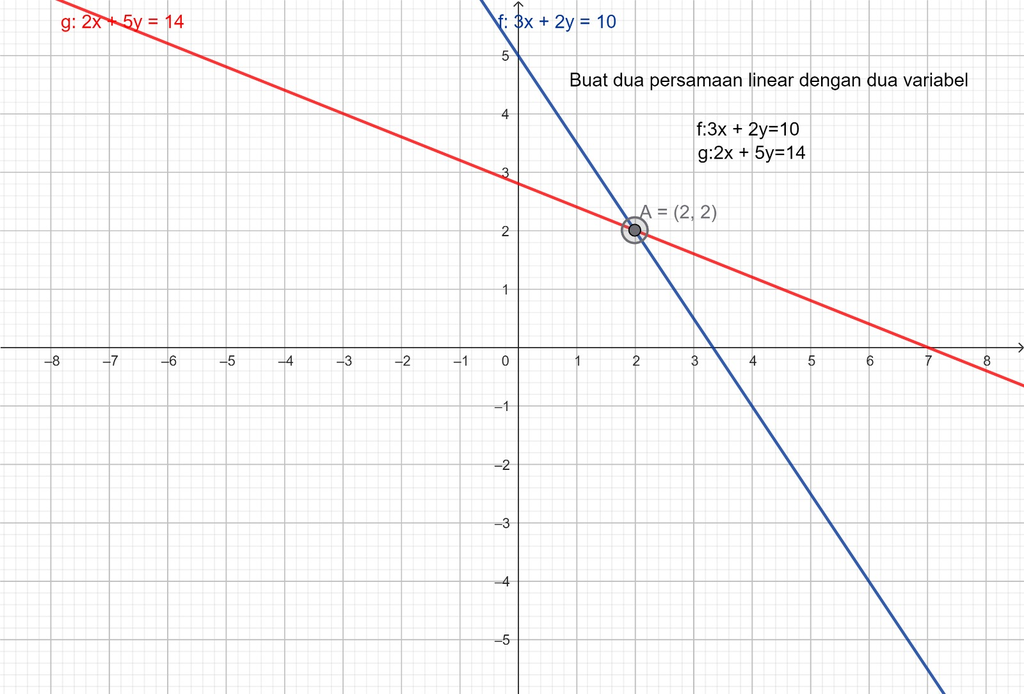

```python
from IPython.display import Image
Image(filename="persamaan 2.jpeg")
```